# 1. Introduction

## 4.10 Population Time Series Model

### 4.10.1 SARIMAX Model

#### 4.10.1.1 Rationale for SARIMAX Model

The pm.auto_arima function is automated function to find the best ARIMA model.

#### 4.10.1.2 SARIMAX Model Building

The following code builds best models using the pm.auto_arima function with the Population data. m was set to 1 for nonseasonal data, d and D to None, which means the program will determine them, which seemed to work best.

```python
ts_Pop_to2009 = ts_Pop[:'2009-12-31']
best_model_Pop = pm.auto_arima(ts_Pop_to2009,
                             max_p=3, max_q=3,
                             max_P=3, max_Q=3,
                             m=1, seasonal=False,
                             d=None, D=None, trace=True,
                             information_criterion = 'bic',
                             error_action='ignore',  # don't want to know if an order does not work
                             suppress_warnings=True,  # don't want convergence warnings
                             stepwise=True)  # set to stepwise)
```

```
Performing stepwise search to minimize bic
 ARIMA(2,2,2)(0,0,0)[0] intercept   : BIC=1946.524, Time=0.20 sec
 ARIMA(0,2,0)(0,0,0)[0] intercept   : BIC=1878.531, Time=0.00 sec
 ARIMA(1,2,0)(0,0,0)[0] intercept   : BIC=1888.935, Time=0.03 sec
 ARIMA(0,2,1)(0,0,0)[0] intercept   : BIC=1904.202, Time=0.01 sec
 ARIMA(0,2,0)(0,0,0)[0]             : BIC=1879.625, Time=0.00 sec
 ARIMA(1,2,1)(0,0,0)[0] intercept   : BIC=1917.579, Time=0.01 sec

Best model:  ARIMA(0,2,0)(0,0,0)[0] intercept
Total fit time: 0.255 seconds
```

```python
best_model_Pop.summary()
```

SARIMAX Results

| Dep. Variable: | y | No. Observations: | 60 |
| --- | --- | --- | --- |
| Model: | SARIMAX(0, 2, 0) | Log Likelihood | -935.205 |
| Date: | Thu, 21 Dec 2023 | AIC | 1874.410 |
| Time: | 16:19:48 | BIC | 1878.531 |
| Sample: | 12-31-1950 | HQIC | 1876.015 |
|  | - 12-31-2009 |  |  |
| Covariance Type: | opg |  |  |

|  | coef | std err | z | P>\|z\| | [0.025 | 0.975] |
| --- | --- | --- | --- | --- | --- | --- |
| intercept | 7.397e+05 | 3.71e+05 | 1.992 | 0.046 | 1.18e+04 | 1.47e+06 |
| sigma2 | 5.927e+12 | 6.51e+11 | 9.111 | 0.000 | 4.65e+12 | 7.2e+12 |

| Ljung-Box (L1) (Q): | 19.76 | Jarque-Bera (JB): | 98.57 |
| --- | --- | --- | --- |
| Prob(Q): | 0.00 | Prob(JB): | 0.00 |
| Heteroskedasticity (H): | 0.19 | Skew: | 1.41 |
| Prob(H) (two-sided): | 0.00 | Kurtosis: | 8.73 |

Warnings:  
[1] Covariance matrix calculated using the outer product of gradients (complex-step).

#### 4.10.1.3 SARIMAX Model Results

The best model has SARIMAX parameters (0,2,0), which were used for the forecasting.

```python
# Forecasting Pop
SARIMAX_model_Pop = SARIMAX(ts_Pop_to2009, order=(0,2,0)).fit()
print(SARIMAX_model_Pop.summary())
prediction = SARIMAX_model_Pop.get_forecast(13, dynamic=True).summary_frame()
prediction
```

```
RUNNING THE L-BFGS-B CODE

           * * *

Machine precision = 2.220D-16
 N =            1     M =           10

At X0         0 variables are exactly at the bounds

At iterate    0    f=  1.56297D+01    |proj g|=  1.33226D-08

           * * *

Tit   = total number of iterations
Tnf   = total number of function evaluations
Tnint = total number of segments explored during Cauchy searches
Skip  = number of BFGS updates skipped
Nact  = number of active bounds at final generalized Cauchy point
Projg = norm of the final projected gradient
F     = final function value

           * * *

   N    Tit     Tnf  Tnint  Skip  Nact     Projg        F
    1      0      1      0     0     0   1.332D-08   1.563D+01
  F =   15.629705978034259

CONVERGENCE: NORM_OF_PROJECTED_GRADIENT_<=_PGTOL
                               SARIMAX Results
==============================================================================
Dep. Variable:                    Pop   No. Observations:                   60
Model:               SARIMAX(0, 2, 0)   Log Likelihood                -937.782
Date:                Thu, 21 Dec 2023   AIC                           1877.565
Time:                        16:19:48   BIC                           1879.625
Sample:                    12-31-1950   HQIC                          1878.367
                         - 12-31-2009
Covariance Type:                  opg
==============================================================================
                 coef    std err          z      P>|z|      [0.025      0.975]
------------------------------------------------------------------------------
sigma2      6.259e+12   5.54e+11     11.298      0.000    5.17e+12    7.34e+12
===================================================================================
Ljung-Box (L1) (Q):                  19.76   Jarque-Bera (JB):                98.57
Prob(Q):                              0.00   Prob(JB):                         0.00
Heteroskedasticity (H):               0.11   Skew:                             1.41
Prob(H) (two-sided):                  0.00   Kurtosis:                         8.73
===================================================================================

Warnings:
[1] Covariance matrix calculated using the outer product of gradients (complex-step).
```

```
 This problem is unconstrained.
```

| Pop | mean | mean_se | mean_ci_lower | mean_ci_upper |
| --- | --- | --- | --- | --- |
| 2010-12-31 | 6.985015e+09 | 2.501701e+06 | 6.980111e+09 | 6.989918e+09 |
| 2011-12-31 | 7.071723e+09 | 5.593973e+06 | 7.060759e+09 | 7.082687e+09 |
| 2012-12-31 | 7.158432e+09 | 9.360508e+06 | 7.140086e+09 | 7.176778e+09 |
| 2013-12-31 | 7.245141e+09 | 1.370238e+07 | 7.218285e+09 | 7.271997e+09 |
| 2014-12-31 | 7.331850e+09 | 1.855311e+07 | 7.295486e+09 | 7.368213e+09 |
| 2015-12-31 | 7.418558e+09 | 2.386471e+07 | 7.371784e+09 | 7.465332e+09 |
| 2016-12-31 | 7.505267e+09 | 2.960052e+07 | 7.447251e+09 | 7.563283e+09 |
| 2017-12-31 | 7.591976e+09 | 3.573144e+07 | 7.521943e+09 | 7.662008e+09 |
| 2018-12-31 | 7.678684e+09 | 4.223357e+07 | 7.595908e+09 | 7.761461e+09 |
| 2019-12-31 | 7.765393e+09 | 4.908692e+07 | 7.669184e+09 | 7.861602e+09 |
| 2020-12-31 | 7.852102e+09 | 5.627437e+07 | 7.741806e+09 | 7.962397e+09 |
| 2021-12-31 | 7.938810e+09 | 6.378111e+07 | 7.813802e+09 | 8.063819e+09 |
| 2022-12-31 | 8.025519e+09 | 7.159412e+07 | 7.885197e+09 | 8.165841e+09 |

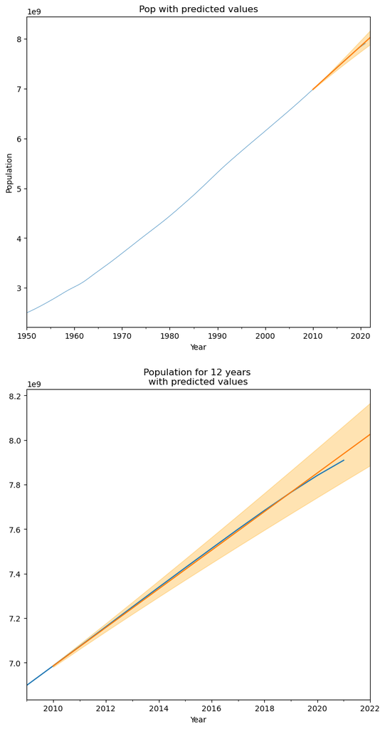

```python
fig, ax = plt.subplots(nrows=2, ncols=1, figsize=(8, 16))

ts_Pop.plot(ax=ax[0], lw=0.5)
prediction['mean'].plot(ax=ax[0])
ax[0].fill_between(prediction.index, prediction['mean_ci_lower'], prediction['mean_ci_upper'], color='orange', alpha=0.3)
ax[0].set_title('Pop with predicted values')
ax[0].set_ylabel('Population')
ax[0].set_xlabel('Year')

ts_Pop['2009-01-31':].plot(ax=ax[1])
prediction['mean'].plot(ax=ax[1])
ax[1].fill_between(prediction.index, prediction['mean_ci_lower'], prediction['mean_ci_upper'], color='orange', alpha=0.3)
ax[1].set_title('Population for 12 years \nwith predicted values')
ax[1].set_xlabel('Year')
```

**Figure 4.10.1.3** This forecast made a very good prediction close to the actual values. The actual values are well within the confidence interval of the prediction.

## 4.11 CO2 Time Series Model

### 4.11.1 SARIMAX Model

#### 4.11.1.1 Rationale for SARIMAX Model

The pm.auto_arima function is automated function to find the best ARIMA model.

#### 4.11.1.2 SARIMAX Model Building

The following code builds best models using the pm.auto_arima function with the CO2 data. m was set to 1 for nonseasonal data, d and D to None, which means the program will determine them, which seemed to work best.

```python
ts_CO2_to2009 = ts_CO2[:'2009-12-31']
best_model_CO2 = pm.auto_arima(ts_CO2_to2009,
                             max_p=3, max_q=3,
                             max_P=3, max_Q=3,
                             m=1, seasonal=False,
                             d=None, D=None, trace=True,
                             information_criterion = 'bic',
                             error_action='ignore',  # don't want to know if an order does not work
                             suppress_warnings=True,  # don't want convergence warnings
                             stepwise=True)  # set to stepwise)
```

```
Performing stepwise search to minimize bic
 ARIMA(2,2,2)(0,0,0)[0] intercept   : BIC=10697.534, Time=0.07 sec
 ARIMA(0,2,0)(0,0,0)[0] intercept   : BIC=10774.294, Time=0.01 sec
 ARIMA(1,2,0)(0,0,0)[0] intercept   : BIC=10752.171, Time=0.01 sec
 ARIMA(0,2,1)(0,0,0)[0] intercept   : BIC=10700.818, Time=0.01 sec
 ARIMA(0,2,0)(0,0,0)[0]             : BIC=10768.764, Time=0.01 sec
 ARIMA(1,2,2)(0,0,0)[0] intercept   : BIC=10695.033, Time=0.05 sec
 ARIMA(0,2,2)(0,0,0)[0] intercept   : BIC=10691.662, Time=0.02 sec
 ARIMA(0,2,3)(0,0,0)[0] intercept   : BIC=10702.443, Time=0.03 sec
 ARIMA(1,2,1)(0,0,0)[0] intercept   : BIC=10693.135, Time=0.03 sec
 ARIMA(1,2,3)(0,0,0)[0] intercept   : BIC=10698.456, Time=0.09 sec
 ARIMA(0,2,2)(0,0,0)[0]             : BIC=10686.740, Time=0.02 sec
 ARIMA(0,2,1)(0,0,0)[0]             : BIC=10695.746, Time=0.01 sec
 ARIMA(1,2,2)(0,0,0)[0]             : BIC=10691.089, Time=0.04 sec
 ARIMA(0,2,3)(0,0,0)[0]             : BIC=10691.155, Time=0.03 sec
 ARIMA(1,2,1)(0,0,0)[0]             : BIC=10689.678, Time=0.02 sec
 ARIMA(1,2,3)(0,0,0)[0]             : BIC=10693.373, Time=0.11 sec

Best model:  ARIMA(0,2,2)(0,0,0)[0]
Total fit time: 0.549 seconds
```

#### 4.11.1.3 SARIMAX Model Results

The best model has SARIMAX parameters (0,2,2), which were used for the forecasting.

```python
# Forecasting CO2
SARIMAX_model_CO2 = SARIMAX(ts_CO2_to2009, order=(0,2,2)).fit()
print(SARIMAX_model_CO2.summary())
prediction = SARIMAX_model_CO2.get_forecast(13, dynamic=True).summary_frame()
prediction
```

```
RUNNING THE L-BFGS-B CODE

           * * *

Machine precision = 2.220D-16
 N =            3     M =           10

At X0         0 variables are exactly at the bounds

At iterate    0    f=  2.05319D+01    |proj g|=  4.04797D-02

At iterate    5    f=  2.05194D+01    |proj g|=  4.62091D-05

           * * *

Tit   = total number of iterations
Tnf   = total number of function evaluations
Tnint = total number of segments explored during Cauchy searches
Skip  = number of BFGS updates skipped
Nact  = number of active bounds at final generalized Cauchy point
Projg = norm of the final projected gradient
F     = final function value

           * * *

   N    Tit     Tnf  Tnint  Skip  Nact     Projg        F
    3      6      8      1     0     0   8.843D-07   2.052D+01
  F =   20.519386582590204

CONVERGENCE: NORM_OF_PROJECTED_GRADIENT_<=_PGTOL
                               SARIMAX Results
==============================================================================
Dep. Variable:                    CO2   No. Observations:                  260
Model:               SARIMAX(0, 2, 2)   Log Likelihood               -5335.041
Date:                Thu, 21 Dec 2023   AIC                          10676.081
Time:                        16:19:49   BIC                          10686.740
Sample:                    12-31-1750   HQIC                         10680.367
                         - 12-31-2009
Covariance Type:                  opg
==============================================================================
                 coef    std err          z      P>|z|      [0.025      0.975]
------------------------------------------------------------------------------
ma.L1         -0.6351      0.045    -14.046      0.000      -0.724      -0.546
ma.L2         -0.2708      0.043     -6.270      0.000      -0.356      -0.186
sigma2      6.106e+16   6.47e-20   9.44e+35      0.000    6.11e+16    6.11e+16
===================================================================================
Ljung-Box (L1) (Q):                   0.11   Jarque-Bera (JB):               545.85
Prob(Q):                              0.74   Prob(JB):                         0.00
Heteroskedasticity (H):            9614.67   Skew:                            -0.87
Prob(H) (two-sided):                  0.00   Kurtosis:                         9.91
===================================================================================

Warnings:
[1] Covariance matrix calculated using the outer product of gradients (complex-step).
[2] Covariance matrix is singular or near-singular, with condition number 1.38e+52. Standard errors may be unstable.
```

```
 This problem is unconstrained.
```

| CO2 | mean | mean_se | mean_ci_lower | mean_ci_upper |
| --- | --- | --- | --- | --- |
| 2010-12-31 | 3.166190e+10 | 2.470983e+08 | 3.117759e+10 | 3.214620e+10 |
| 2011-12-31 | 3.212521e+10 | 4.181062e+08 | 3.130573e+10 | 3.294468e+10 |
| 2012-12-31 | 3.258852e+10 | 5.520825e+08 | 3.150645e+10 | 3.367058e+10 |
| 2013-12-31 | 3.305183e+10 | 6.723734e+08 | 3.173400e+10 | 3.436965e+10 |
| 2014-12-31 | 3.351514e+10 | 7.859815e+08 | 3.197464e+10 | 3.505563e+10 |
| 2015-12-31 | 3.397845e+10 | 8.960577e+08 | 3.222221e+10 | 3.573469e+10 |
| 2016-12-31 | 3.444176e+10 | 1.004303e+09 | 3.247336e+10 | 3.641016e+10 |
| 2017-12-31 | 3.490507e+10 | 1.111740e+09 | 3.272610e+10 | 3.708404e+10 |
| 2018-12-31 | 3.536838e+10 | 1.219025e+09 | 3.297913e+10 | 3.775762e+10 |
| 2019-12-31 | 3.583169e+10 | 1.326603e+09 | 3.323160e+10 | 3.843178e+10 |
| 2020-12-31 | 3.629500e+10 | 1.434786e+09 | 3.348287e+10 | 3.910713e+10 |
| 2021-12-31 | 3.675831e+10 | 1.543795e+09 | 3.373253e+10 | 3.978409e+10 |
| 2022-12-31 | 3.722162e+10 | 1.653796e+09 | 3.398024e+10 | 4.046300e+10 |

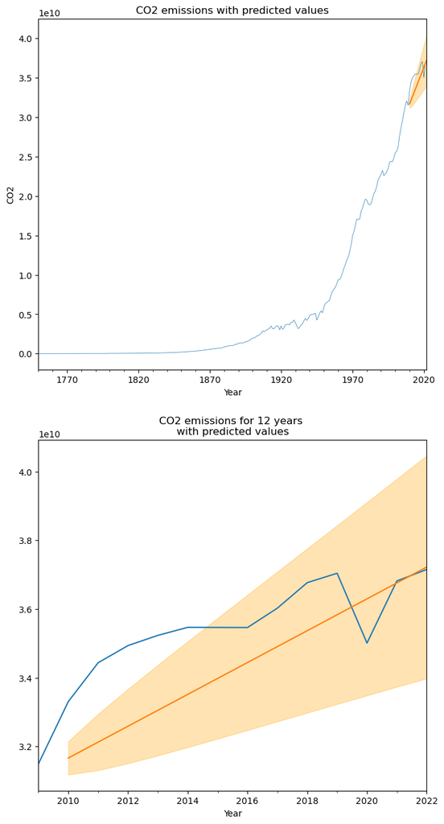

```python
fig, ax = plt.subplots(nrows=2, ncols=1, figsize=(8, 16))

ts_CO2.plot(ax=ax[0], lw=0.5)
prediction['mean'].plot(ax=ax[0])
ax[0].fill_between(prediction.index, prediction['mean_ci_lower'], prediction['mean_ci_upper'], color='orange', alpha=0.3)
ax[0].set_title('CO2 emissions with predicted values')
ax[0].set_ylabel('CO2')
ax[0].set_xlabel('Year')

ts_CO2['2009-01-31':].plot(ax=ax[1])
prediction['mean'].plot(ax=ax[1])
ax[1].fill_between(prediction.index, prediction['mean_ci_lower'], prediction['mean_ci_upper'], color='orange', alpha=0.3)
ax[1].set_title('CO2 emissions for 12 years \nwith predicted values')
ax[1].set_xlabel('Year')
```

**Figure 4.11.1.3** The CO2 emissions could be predicted quite accurately for the latter portion of the forecast period and the actual values in that part of the period are within the confidence interval of prediction.

## 4.12 Methane Time Series Model

### 4.12.1 SARIMAX Model

#### 4.12.1.1 Rationale for SARIMAX Model

The pm.auto_arima function is automated function to find the best ARIMA model.

#### 4.12.1.2 SARIMAX Model Building

The following code builds best models using the pm.auto_arima function with the Methane data. m was set to 1 for nonseasonal data, d and D to None, which means the program will determine them, which seemed to work best.

```python
ts_Methane_to2009 = ts_Methane[:'2009-12-31']
best_model_Methane = pm.auto_arima(ts_Methane_to2009,
                             max_p=3, max_q=3,
                             max_P=3, max_Q=3,
                             m=1, seasonal=False,
                             d=None, D=None, trace=True,
                             information_criterion = 'bic',
                             error_action='ignore',  # don't want to know if an order does not work
                             suppress_warnings=True,  # don't want convergence warnings
                             stepwise=True)  # set to stepwise)
```

```
Performing stepwise search to minimize bic
 ARIMA(2,2,2)(0,0,0)[0] intercept   : BIC=6109.538, Time=0.05 sec
 ARIMA(0,2,0)(0,0,0)[0] intercept   : BIC=6119.984, Time=0.01 sec
 ARIMA(1,2,0)(0,0,0)[0] intercept   : BIC=6121.410, Time=0.01 sec
 ARIMA(0,2,1)(0,0,0)[0] intercept   : BIC=6120.508, Time=0.01 sec
 ARIMA(0,2,0)(0,0,0)[0]             : BIC=6114.939, Time=0.00 sec
 ARIMA(1,2,2)(0,0,0)[0] intercept   : BIC=6106.077, Time=0.04 sec
 ARIMA(0,2,2)(0,0,0)[0] intercept   : BIC=6104.528, Time=0.02 sec
 ARIMA(0,2,3)(0,0,0)[0] intercept   : BIC=6104.993, Time=0.05 sec
 ARIMA(1,2,1)(0,0,0)[0] intercept   : BIC=6099.680, Time=0.02 sec
 ARIMA(2,2,1)(0,0,0)[0] intercept   : BIC=6101.495, Time=0.03 sec
 ARIMA(2,2,0)(0,0,0)[0] intercept   : BIC=6116.061, Time=0.01 sec
 ARIMA(1,2,1)(0,0,0)[0]             : BIC=6092.212, Time=0.02 sec
 ARIMA(0,2,1)(0,0,0)[0]             : BIC=6115.386, Time=0.01 sec
 ARIMA(1,2,0)(0,0,0)[0]             : BIC=6116.359, Time=0.01 sec
 ARIMA(2,2,1)(0,0,0)[0]             : BIC=6095.426, Time=0.03 sec
 ARIMA(1,2,2)(0,0,0)[0]             : BIC=6095.232, Time=0.04 sec
 ARIMA(0,2,2)(0,0,0)[0]             : BIC=6097.764, Time=0.02 sec
 ARIMA(2,2,0)(0,0,0)[0]             : BIC=6110.967, Time=0.01 sec
 ARIMA(2,2,2)(0,0,0)[0]             : BIC=6100.418, Time=0.07 sec

Best model:  ARIMA(1,2,1)(0,0,0)[0]
Total fit time: 0.483 seconds
```

#### 4.12.1.3 SARIMAX Model Results

The best model has SARIMAX parameters (1,2,1), which were used for the forecasting.

```python
# Forecasting methane
SARIMAX_model_Methane = SARIMAX(ts_Methane_to2009, order=(1,2,1)).fit()
print(SARIMAX_model_Methane.summary())
prediction = SARIMAX_model_Methane.get_forecast(13, dynamic=True).summary_frame()
prediction
```

```
RUNNING THE L-BFGS-B CODE

           * * *

Machine precision = 2.220D-16
 N =            3     M =           10

At X0         0 variables are exactly at the bounds

At iterate    0    f=  1.90658D+01    |proj g|=  4.59222D-01

At iterate    5    f=  1.89971D+01    |proj g|=  3.77531D-02

At iterate   10    f=  1.89907D+01    |proj g|=  4.72765D-04

           * * *

Tit   = total number of iterations
Tnf   = total number of function evaluations
Tnint = total number of segments explored during Cauchy searches
Skip  = number of BFGS updates skipped
Nact  = number of active bounds at final generalized Cauchy point
Projg = norm of the final projected gradient
F     = final function value

           * * *

   N    Tit     Tnf  Tnint  Skip  Nact     Projg        F
    3     13     15      1     0     0   3.041D-07   1.899D+01
  F =   18.990701292110305

CONVERGENCE: NORM_OF_PROJECTED_GRADIENT_<=_PGTOL
                               SARIMAX Results
==============================================================================
Dep. Variable:                Methane   No. Observations:                  160
Model:               SARIMAX(1, 2, 1)   Log Likelihood               -3038.512
Date:                Thu, 21 Dec 2023   AIC                           6083.024
Time:                        16:19:49   BIC                           6092.212
Sample:                    12-31-1850   HQIC                          6086.756
                         - 12-31-2009
Covariance Type:                  opg
==============================================================================
                 coef    std err          z      P>|z|      [0.025      0.975]
------------------------------------------------------------------------------
ar.L1          0.5954      0.046     13.059      0.000       0.506       0.685
ma.L1         -0.9538      0.027    -35.427      0.000      -1.007      -0.901
sigma2      3.006e+15   7.02e-19   4.28e+33      0.000    3.01e+15    3.01e+15
===================================================================================
Ljung-Box (L1) (Q):                   2.57   Jarque-Bera (JB):                43.66
Prob(Q):                              0.11   Prob(JB):                         0.00
Heteroskedasticity (H):              10.80   Skew:                             0.10
Prob(H) (two-sided):                  0.00   Kurtosis:                         5.57
===================================================================================

Warnings:
[1] Covariance matrix calculated using the outer product of gradients (complex-step).
[2] Covariance matrix is singular or near-singular, with condition number 4.67e+49. Standard errors may be unstable.
```

```
 This problem is unconstrained.
```

| Methane | mean | mean_se | mean_ci_lower | mean_ci_upper |
| --- | --- | --- | --- | --- |
| 2010-12-31 | 9.287748e+09 | 5.482326e+07 | 9.180296e+09 | 9.395199e+09 |
| 2011-12-31 | 9.317630e+09 | 1.053787e+08 | 9.111091e+09 | 9.524168e+09 |
| 2012-12-31 | 9.364775e+09 | 1.548523e+08 | 9.061270e+09 | 9.668280e+09 |
| 2013-12-31 | 9.422200e+09 | 2.021677e+08 | 9.025959e+09 | 9.818441e+09 |
| 2014-12-31 | 9.485744e+09 | 2.472433e+08 | 9.001156e+09 | 9.970332e+09 |
| 2015-12-31 | 9.552932e+09 | 2.903433e+08 | 8.983870e+09 | 1.012199e+10 |
| 2016-12-31 | 9.622290e+09 | 3.318174e+08 | 8.971940e+09 | 1.027264e+10 |
| 2017-12-31 | 9.692939e+09 | 3.720032e+08 | 8.963826e+09 | 1.042205e+10 |
| 2018-12-31 | 9.764357e+09 | 4.111945e+08 | 8.958430e+09 | 1.057028e+10 |
| 2019-12-31 | 9.836232e+09 | 4.496354e+08 | 8.954963e+09 | 1.071750e+10 |
| 2020-12-31 | 9.908381e+09 | 4.875245e+08 | 8.952850e+09 | 1.086391e+10 |
| 2021-12-31 | 9.980692e+09 | 5.250214e+08 | 8.951668e+09 | 1.100971e+10 |
| 2022-12-31 | 1.005310e+10 | 5.622545e+08 | 8.951100e+09 | 1.115510e+10 |

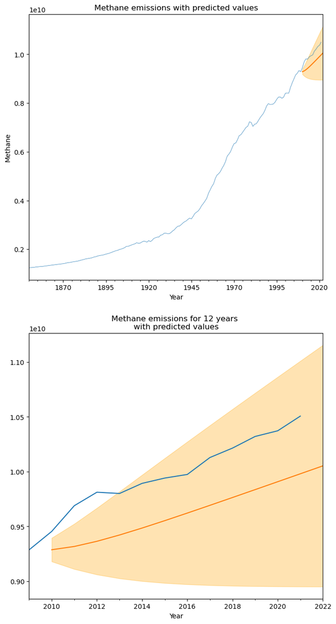

```python
fig, ax = plt.subplots(nrows=2, ncols=1, figsize=(8, 16))

ts_Methane.plot(ax=ax[0], lw=0.5)
prediction['mean'].plot(ax=ax[0])
ax[0].fill_between(prediction.index, prediction['mean_ci_lower'], prediction['mean_ci_upper'], color='orange', alpha=0.3)
ax[0].set_title('Methane emissions with predicted values')
ax[0].set_ylabel('Methane')
ax[0].set_xlabel('Year')

ts_Methane['2009-01-31':].plot(ax=ax[1])
prediction['mean'].plot(ax=ax[1])
ax[1].fill_between(prediction.index, prediction['mean_ci_lower'], prediction['mean_ci_upper'], color='orange', alpha=0.3)
ax[1].set_title('Methane emissions for 12 years \nwith predicted values')
ax[1].set_xlabel('Year')
```

# 5. Conclusions

The question whether human activity is responsible for global warming was explored. The following measures related to global warming were evaluated:

- Global average surface temperature
- World population
- Greenhouse gas emissions (CO2 and Methane combined account for more than 90% of all greenhouse gas emissions).
- Global gross domestic product (GDP).

Data was obtained from publicly accessible databases,such as NASA, ourworldindata.org, or the World Bank. The data exploration showed that all these measures have increased over the periods for which the data was available, which varied from 1750 to today to 1960 to today. The data exploration also showed that many of these measures have strong correlations between themselves.

The data was analyzed in more detail by building various linear models, stratifying the data based on country category (based on income), and by building time series models.

## 5.1 Results from Different Linear Models

Below is a summary of the different linear models built. There are very strong correlations between temperature and population (Section 4.1), temperature and greenhouse gas emissions (Section 4.2) and temperature and interaction terms of population and greenhouse gas emissions (Section 4.5), as can be seen in the data frame in terms of high adjusted R squared and small RMSE (which are given in degree Celsius).

There were also strong correlations between greenhouse gas emission and population (Section 4.3) and between Box-Cox-transformed GDP and population (Section 4.4).

All these models strongly hint at humans affecting the global temperature via greenhouse gas emissions.

```python
LM_Summary = pd.read_csv('Summaries/LinearModels.csv')
LM_Summary
```

|  | Variables used | Section | Model used | adjusted R squared | RMSE | Residuals normally distributed | Residuals homoskedastic |
| --- | --- | --- | --- | --- | --- | --- | --- |
| 0 | Temp vs. Population | 4.1 | Linear Model | 0.897 | 0.106 | Yes | Yes |
| 1 | TempS vs. Population | 4.1 | Linear Model | 0.961 | 0.062 | No | No |
| 2 | Temp vs. GGE | 4.2 | Linear Model | 0.864 | 0.121 | Yes | No |
| 3 | TempS vs. GGE | 4.2 | Linear Model | 0.928 | 0.085 | No | No |
| 4 | Temp vs. Population x GGE | 4.5 | Multivariate Linear Model | 0.912 | 0.097 | Yes | Yes |
| 5 | TempS vs. Population x GGE | 4.5 | Multivariate Linear Model | 0.979 | 0.046 | No | Yes |
| 6 | GGE vs. Population | 4.3 | Linear Model | 0.983 | 1.4 billion | Yes | Yes |
| 7 | GDP vs. Population | 4.4 | BoxCox Linear Model | 0.988 | 125.5 | No | Yes |

## 5.2 Results from Stratification

Stratification of population and greenhouse gas emissions allowed for determining which country category plays the biggest roles for different measures. These roles are indicated by a rank in the data frame below. For example, lower-middle-income countries play the biggest role in terms of population and have rank 1 in that category. When multivariate linear models were built and a country did not have a significant contribution to that measure, it obtained a rank of 0.

In summary

One positive observation is that although high-income countries rank highest in greenhouse gas emissions per capita, they rank lowest in greenhouse gas emissions increase (total and per capita). Apparently, technology available to them has helped them decrease their greenhouse gas emissions. If this technology will become available to all countries, this could significantly help decrease greenhouse gas emissions and fight global warming.

```python
Stratification = pd.read_csv('Summaries/Stratification.csv')
Stratification
```

|  | Country category | Source | High-income countries | Upper-middle-income countries | Lower-middle-income countries | low-income countries |
| --- | --- | --- | --- | --- | --- | --- |
| 0 | Population rank | Figure 3.3.1 | 3 | 2 | 1 | 4 |
| 1 | Population increase rank | Figure 3.3.1 | 4 | 3 | 1 | 2 |
| 2 | GGE rank | Figure 3.3.2 | 2 | 1 | 3 | 4 |
| 3 | GGE increase rank | Figure 3.3.2 | 4 | 1 | 2 | 3 |
| 4 | GGE per capita rank | Figure 3.3.3 | 1 | 2 | 3 | 4 |
| 5 | GGE per capita increase rank | Figure 3.3.3 | 4 | 1 | 2 | 3 |
| 6 | Country Pop trend similar to world Pop trend | Section 4.6 | 4 | 2 | 1 | 3 |
| 7 | Country category GGE trend similar to world GG... | Section 4.7 | 0 | 2 | 1 | 0 |
| 8 | Country category Pop and GGE trend similar to ... | Section 4.8 | 0 | 1 | 0 | 2 |
| 9 | Country category Pop and GGE trend similar to ... | Section 4.8 | 0 | 1 | 2 | 3 |

## 5.3 Results from Time Series Models

The data frame below summarizes the time series models that were built for the different data sets with the SARIMAX program. For all forecasts since 2010, the data went into the right direction and for Temp, TempS, and population, all actual values were within the confidence intervals of the predictions, while for CO2 and Methane emissions most but not all of those values were within the confidence intervals of the predictions.

```python
TS_Summary = pd.read_csv('Summaries/TimeSeriesModels.csv')
TS_Summary
```

|  | Time Series Models | Source | ARIMA parameters | Right direction | Actual values with prediction Cis |
| --- | --- | --- | --- | --- | --- |
| 0 | Temp | Section 4.9 | (0,3,2) | Yes | Yes |
| 1 | TempS | Section 4.9 | (0,3,2) | Yes | Yes |
| 2 | Population | Section 4.10 | (0.2,0) | Yes | Yes |
| 3 | CO2 | Section 4.11 | (0,2,2) | Yes | Mostly |
| 4 | Methane | Section 4.12 | (1,2,1) | Yes | Mostly |

## 5.4 Outlook

There are no limits to what else could be studied related to this topic. All studies that were done for the entire world, could be done for country categories, as was done in part in the Stratification sections, or for individual countries. In addition, many more measures could be included, such as, what the energy mix of different countries is, how much traffic they have, and how much they invest in energy conservation and clean energy technology. I hope that this project gives a small but convincing insight into the problem of human-caused global warming.